# Class 8 - In class exercises

Ian Hollands

Date created: 2019-04-02

## Task Set 1: Correct me

```r
library(nycflights13); library(tidyverse)
meanCarrierDelays <- flights %>%
    group_by(carrier) %>%
    summarise(meanDelay = mean(dep_delay, na.rm = T))
```

```r
flights %>%
    group_by(origin) %>%
    summarise(medianDelay = median(dep_delay, na.rm = T),
              stdDevDelay = sd(dep_delay, na.rm = T)
    )
```

| origin | medianDelay | stdDevDelay |
| --- | --- | --- |
| EWR | -1 | 41.32370 |
| JFK | -1 | 39.03507 |
| LGA | -3 | 39.99302 |

```r
##this code fails silently. Correct it so that the newDate column shows the actual date
flights %>%
    mutate(newDate = paste(year, month, day, sep = "-")) %>%
    select(1:3, newDate)
```

| year | month | day | newDate |
| --- | --- | --- | --- |
| 2013 | 1 | 1 | 2013-1-1 |
| 2013 | 1 | 1 | 2013-1-1 |
| 2013 | 1 | 1 | 2013-1-1 |
| 2013 | 1 | 1 | 2013-1-1 |
| 2013 | 1 | 1 | 2013-1-1 |
| 2013 | 1 | 1 | 2013-1-1 |
| 2013 | 1 | 1 | 2013-1-1 |
| 2013 | 1 | 1 | 2013-1-1 |
| 2013 | 1 | 1 | 2013-1-1 |
| 2013 | 1 | 1 | 2013-1-1 |

[output cut: 990 more lines]

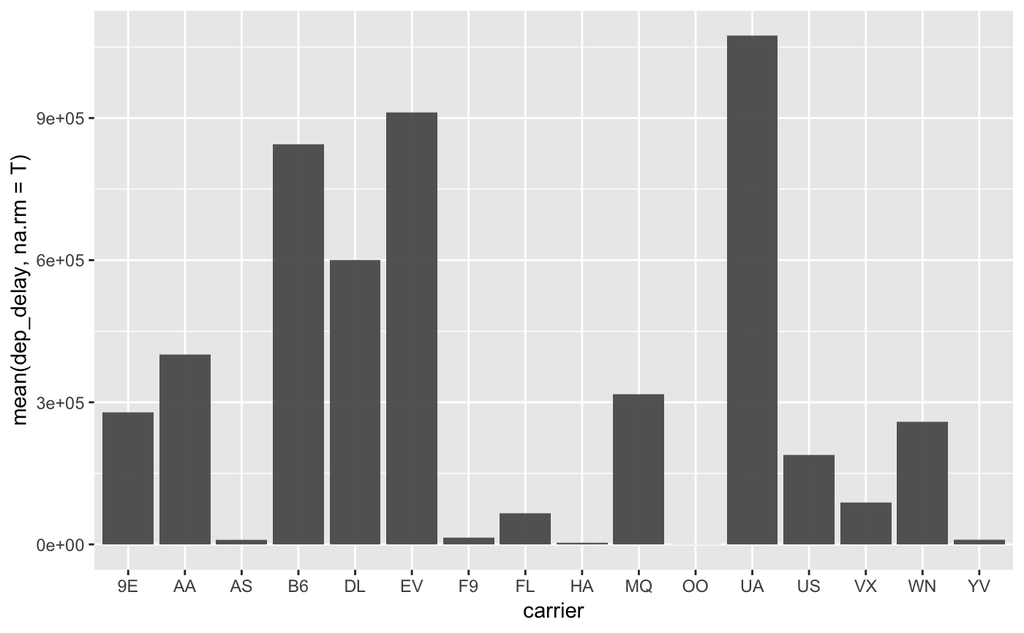

```r
##This code fails silently. I would like a column chart that shows the average departure delay for each carrier, this chart is showing me something else entirely.
flights %>%
    filter(dep_delay > 0) %>%
    ggplot(aes(x = carrier, y = mean(dep_delay, na.rm = T))) +
    geom_col()
```

**Hard Task**: Can you explain the chart that was being plotted in the above chunk before you corrected it?

## Task Set 2: Dplyr reminder

1. Complete the code below to select the first 3 columns, `dep_delay` and `carrier` columns from flights data.

```r
flights %>%
    select()
```

2. Filter all flights that were delayed by more than 2 hours.
3. Complete the following code to create a new variable that is the difference between `dep_delay` and `arr_delay`

```r
flights %>%
    select(1:3, carrier, dep_delay, arr_delay) %>%
```

4. Calculate the average arrival delay in 2013 using `summarise()`

```r
flights %>%
    summarise()
```

## Task Set 3: Grouping

1. Modify the code below to find the mean monthly delay for every origin.

```r
flights %>%
    group_by(origin) %>%
    summarise(meanDelay = mean(dep_delay, na.rm = T))
```

2. Explain how this code works.

```r
flights %>%
    group_by(origin) %>%
    filter(dep_delay == max(dep_delay, na.rm = T))
```

3. Modify the code above to filter the flights that were the most delayed for each month for each origin.
4. Would this code yield the same output if it were not grouped? Try to answer this without trying out the code first.

```r
flights %>%
    group_by(origin) %>%
    filter(dep_delay > 120) %>%
    ungroup()
```

5. Add a new column to the flights dataset using `group_by()` and `mutate()` that is the deviation of each flight `dep_delay` from monthly average departure delay.